# Управление системными службами

Майоров Дмитрий Андреевич

## Докладчик

- Майоров Дмитрий Андреевич

# Цель работы

Получить навыки управления системными службами операционной системы посредством systemd

# Выполнение лабораторной работы

Получаем полномочия администратора. Проверяем статус службы Very Secure FTP.(сервис в настоящее время отключен) Устанаваливаем данную службу

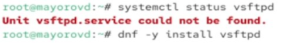

Рисунок 1

# Выполнение лабораторной работы

Запускаем службу и проверяем ее статус. Служба в настоящее время работает, но не будет активирована при перезапуске операционной системы.

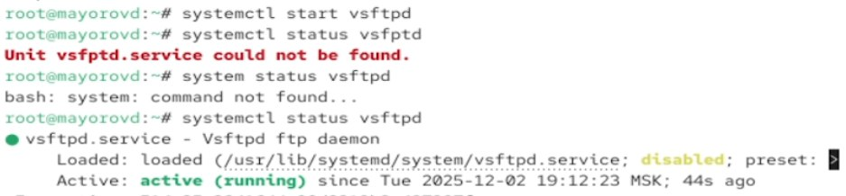

Рисунок 2

# Выполнение лабораторной работы

# Выполнение лабораторной работы

Выводим на экран символические ссылки и снова добавляем службу в автозапуск

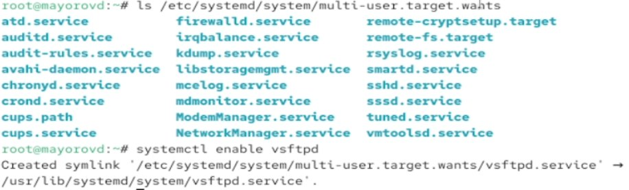

Рисунок 4

# Выполнение лабораторной работы

Снова проверяем статус службы

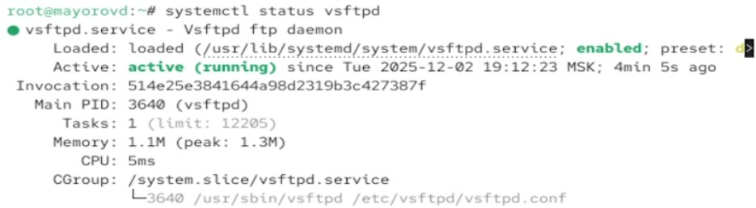

Рисунок 5

# Выполнение лабораторной работы

Выводим на экарн список зависимостей юнита

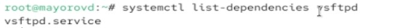

Рисунок 6

# Выполнение лабораторной работы

Устанавливаем iptables. Проверяем статус firewalld и iptables

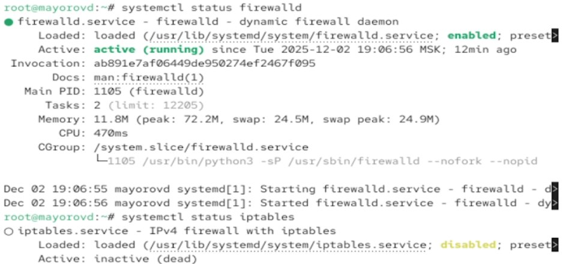

Рисунок 7

# Выполнение лабораторной работы

Пробуем запустить firewalld и iptables

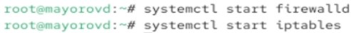

Рисунок 8

# Выполнение лабораторной работы

Выгружаем iptables и загружаем firewalld. Блокируем запуск iptables.

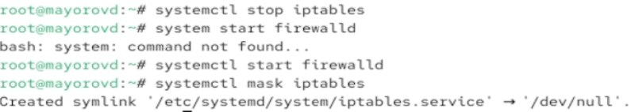

Рисунок 9

# Выполнение лабораторной работы

Пробуем запустить iptables и добавить его в автозапуск. Сервис неактивен, а статус загрузки отображается как замаскированный

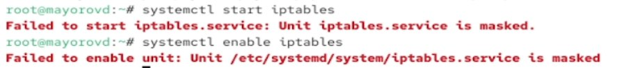

Рисунок 10

# Выполнение лабораторной работы

Получаем список всех активных загруженных целей.

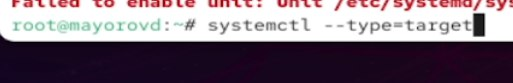

Рисунок 11

# Выполнение лабораторной работы

Переходим в каталог systemd и находим список всех целей, которые можно изолировать.

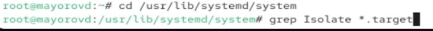

Рисунок 12

# Выполнение лабораторной работы

Переключаем ОС в режим восстановления и перезапускаем ее

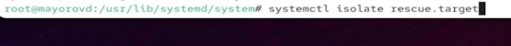

Рисунок 13

# Выполнение лабораторной работы

Выводим на экран цель, установленную по умолчанию. Устаанваливаем текстовый режим по умолчанию. Перезагружаем систему

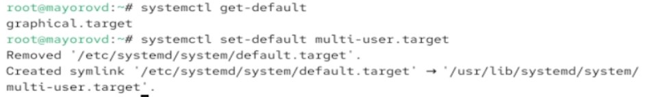

Рисунок 14

# Выполнение лабораторной работы

Устанаваливаем графический режим по умолчанию и перезапускаем систему

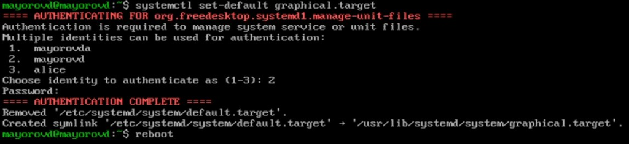

Рисунок 15

# Выводы

Мы получили навыки управления системными службами операционной системы посредством systemd